# HW03

Jiuru Lyu

2022-09-16

Import `gss` data set:

```r
gss <- read.csv('gss.csv')
```

# Question 1

- **How many missing values for the variable marital?**

```r
sum(is.na(gss$marital))
```

```
## [1] 20
```

Hence, there are 20 missing values fro the variable marital.

- **What is the percentage of female respondents (excluding missing values), try function prop.table()?**

```r
prop.table(table(gss$sex))
```

```
##
##    FEMALE      MALE
## 0.5614317 0.4385683
```

The percentage of female respondents is 0.5614317 (56.1%).

- **What is the percentage of male respondents who felt “NOT TOO HAPPY”?**

```r
prop.table(table(gss$sex, gss$happy), margin = 1)
```

```
##
##                    DK NOT TOO HAPPY PRETTY HAPPY   VERY HAPPY
##   FEMALE 7.303268e-05  1.251050e-01 5.531130e-01 3.217090e-01
##   MALE   0.000000e+00  1.203201e-01 5.688881e-01 3.107918e-01
```

The percentage of male respondents who felt “NOT TOO HAPPY” is 0.1203201 (12.0%).

- **What is the percentage of married respondents who age between 30 and 40 (including the boundaries)?**

As `age` column is a numeric column, I need to convert it into character values before creating the prop.table.

```r
gss$age1 <- factor(NA, levels = c("Below 30", "Between 30 and 40", "Above 40"))

gss$age1[gss$age < 30] <- "Below 30"
gss$age1[gss$age >= 30 | gss$age <=40] <- "Between 30 and 40"
gss$age1[gss$age > 40] <- "Above 40"
```

Let’s check if the factor is created correctly:

```r
summary(gss$age1)
```

```
##          Below 30 Between 30 and 40          Above 40              NA's
##                 0             24106             29179               189
```

```r
prop.table(table(gss$marital, gss$age1), margin = 1)
```

```
##
##                   Below 30 Between 30 and 40   Above 40
##   DIVORCED      0.00000000        0.34379222 0.65620778
##   MARRIED       0.00000000        0.41880282 0.58119718
##   NEVER MARRIED 0.00000000        0.79818615 0.20181385
##   SEPARATED     0.00000000        0.50080343 0.49919657
##   WIDOWED       0.00000000        0.03311513 0.96688487
```

- **What is the average age of female married respondents who took the survey from 1999 and 2010?**

Firstly, we want to select the relevant data that we need.

```r
marriedF <- gss$age[gss$sex == "FEMALE" & gss$marital == "MARRIED"]

marriedF_99_10 <- marriedF[gss$year >= 1999 | gss$year <= 2010]
```

Now, we can calculate the average age. Because there are missing values, we set `na.rm = TRUE`.

```r
mean(marriedF_99_10, na.rm = TRUE)
```

```
## [1] 44.59293
```

# Question 2

- **Make a summary of year. What type of vector is the year variable?**

```r
summary(gss$year)
```

```
##    Min. 1st Qu.  Median    Mean 3rd Qu.    Max.
##    1973    1983    1993    1992    2002    2010
```

The year variable is a numeric variable.

- **It should be treated as a factor variable. Change it into a new factor variable YEAR in the gss data. Make a new summary of YEAR, which year had the most participants?**

```r
gss$year1 <- factor(NA, levels = as.character(c(1973:2010)))

for (i in 1973:2010) {
  gss$year1[gss$year == i] <- as.character(i)
}

summary(gss$year1)
```

```
## 1973 1974 1975 1976 1977 1978 1979 1980 1981 1982 1983 1984 1985 1986 1987 1988
## 1504 1484 1490 1499 1530 1532    0 1468    0 1860 1599 1473 1534 1470 1819 1481
## 1989 1990 1991 1992 1993 1994 1995 1996 1997 1998 1999 2000 2001 2002 2003 2004
## 1537 1372 1517    0 1606 2992    0 2904    0 2832    0 2817    0 2765    0 2812
## 2005 2006 2007 2008 2009 2010
##    0 4510    0 2023    0 2044
```

To find out which year had the most participants, I would like to create a bar plot.

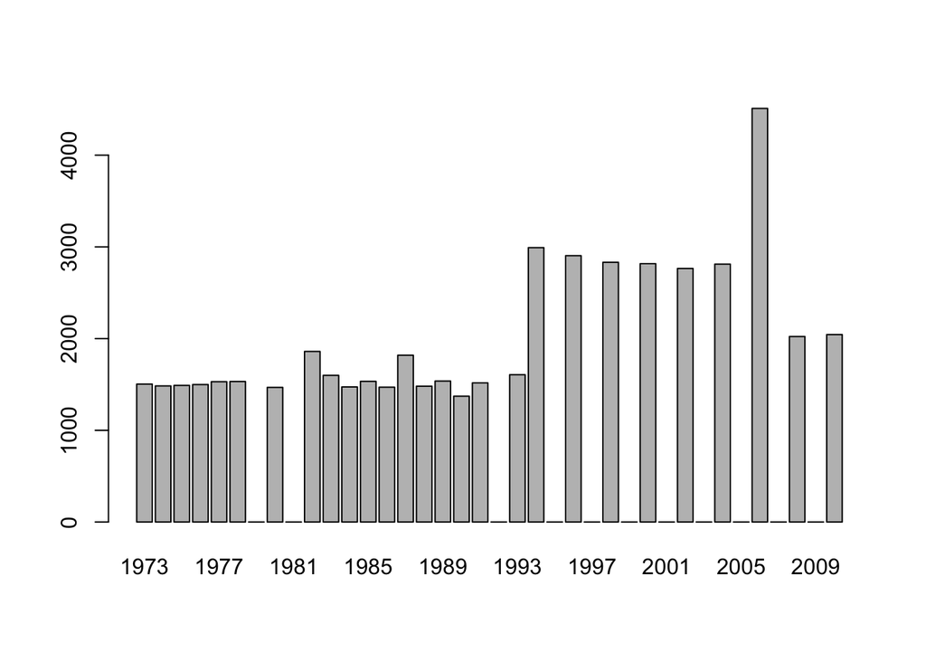

```r
barplot(table(gss$year1))
```

Apparently, year 2006 had the largest number of participants, and the numbe of participants in 2006 was 4510.

- **Use the function tapply to get average age of respondents by YEAR. What years had the oldest and the youngest average age? (look up `tapply()`)**

Firstly, I would like to loop up how to use the function `tapply()`.

```r
?tapply()
```

Now, I am confident to use `tapply()`. I will now start solving this question.

```r
tapply(gss$age, gss$year1, mean, na.rm = TRUE)
```

```
##     1973     1974     1975     1976     1977     1978     1979     1980
## 44.18200 44.59134 44.30774 45.28667 44.66316 44.00984       NA 44.97464
##     1981     1982     1983     1984     1985     1986     1987     1988
##       NA 44.85908 44.29648 44.00477 45.71120 45.43062 44.92363 45.37441
##     1989     1990     1991     1992     1993     1994     1995     1996
## 45.44357 45.95700 45.62616       NA 46.04872 45.96919       NA 44.77709
##     1997     1998     1999     2000     2001     2002     2003     2004
##       NA 45.55693       NA 46.02243       NA 46.28281       NA 45.96468
##     2005     2006     2007     2008     2009     2010
##       NA 47.14159       NA 47.70840       NA 48.04207
```

Hence, the year 1984 had the youngest average age, which is 44.00477, and the year 2010 had the oldest average age, which is 48.04207.

# Question 3

- **Reorder the levels in degree of gss data based on the number of years in education.**

Firstly, we need to conver the degree column into a factor.

```r
gss$degree_factor <- as.factor(gss$degree)
```

Let’s check the levels and the order of the levels:

```r
levels(gss$degree_factor)
```

```
## [1] "BACHELOR"       "GRADUATE"       "HIGH SCHOOL"    "JUNIOR COLLEGE"
## [5] "LT HIGH SCHOOL"
```

We want the levels in an order of the years of education, so we reorder it in the following way:

```r
gss$degree_factor <- factor(gss$degree, levels = c("LT HIGH SCHOOL", "HIGH SCHOOL", "JUNIOR COLLEGE", "BACHELOR", "GRADUATE"))
```

Now, let’s double-check the order:

```r
levels(gss$degree_factor)
```

```
## [1] "LT HIGH SCHOOL" "HIGH SCHOOL"    "JUNIOR COLLEGE" "BACHELOR"
## [5] "GRADUATE"
```

- **Provide the appropriate plot to visualize the distribution of the new degree variable.**

The best way to visualize factor and character data is bar plot:

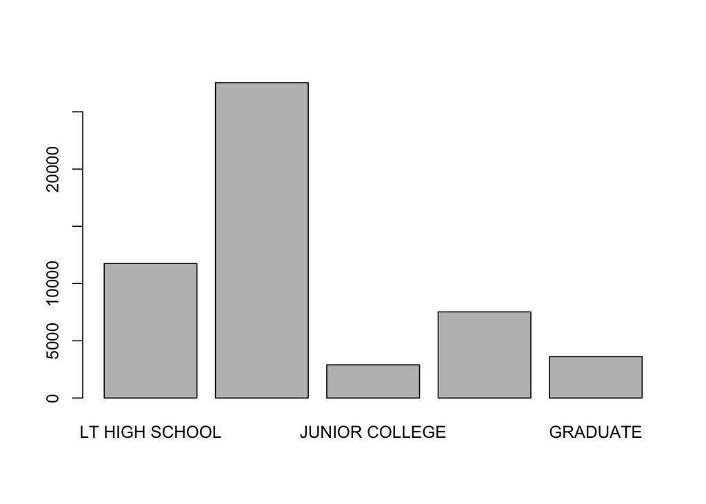

```r
barplot(table(gss$degree_factor))
```